# Variance of Reasons for Failing to Document

Julian Frattini

2026-04-20

This notebook contains the analysis of the variance of responses to the options available for the question “Check as many reasons for failing to document requirements that have applied in at least one circumstance.” across demographic factors. The following options were available to select for this question:

| Code | Name | Text |
| --- | --- | --- |
| `v_670` | Know it by heart | I didn’t need to document it. I know it. |
| `v_671` | Colleagues would complain/ridicule | I knew that if I documented this requirement, my colleagues would complain/hate/ridicule me. |
| `v_672` | Project lead does not care | My project lead told me not to bother. |
| `v_673` | Project lead rushes | My project lead told me not to spend any time on documenting requirements. |
| `v_674` | Project lead considers it a waste | My project lead told me not to waste any time/ anymore time on documenting requirements |
| `v_675` | Colleagues do not care | My colleagues told me not to bother. |
| `v_676` | Colleagues rush | My colleagues told me not to spend any time on documenting requirements. |
| `v_677` | Colleagues consider it a waste | My colleagues told me not to waste any time/ anymore time on documenting requirements. |

For analysis, we follow the 3-step framework for statistical causal inference as summarized by Siebert.[^1]

```r
# short name of the question
q = "reasons for failing to document"
# list of variables representing the options for the question
v <- c("v_670", "v_671", "v_672", "v_673", "v_674", "v_675", "v_676", "v_677")
# names of the options
labels = c("Know it by heart",
           "Colleagues would complain/ridicule",
           "Project lead does not care",
           "Project lead rushes",
           "Project lead considers it a waste",
           "Colleagues do not care",
           "Colleagues rush",
           "Colleagues consider it a waste")

# minimum likelihood of responses to be considered "common"
level.common <- 0.2
```

## Variables

We consider the following demographic factors:

[output not shown]

## Data Analysis

We analyze the variance of the response variable following established practices of Bayesian data analysis.[^2]

```r
d <- load_data(run = "2024", data_path = "../../data", file = "runs/napire2024/data_cleaned_2024.csv") %>%
  select(
    "lfdn", # respondent identifier
    "v_3", "Country", "v_1", "v_457", "v_16", "v_357", "v_377", "v_17", # demographic factors
    all_of(v) # response variables
    ) %>%
  drop_na()

str(d)
```

```
## 'data.frame':    318 obs. of  17 variables:
##  $ lfdn   : int  100 102 104 106 108 109 110 111 115 117 ...
##  $ v_3    : int  20 5 8 20 25 25 9 7 20 6 ...
##  $ Country: chr  "Germany" "Sweden" "Germany" "Sweden" ...
##  $ v_1    : Factor w/ 22 levels "Agriculture",..: 5 2 6 12 6 15 2 2 10 17 ...
##  $ v_457  : Ord.factor w/ 6 levels "Agile"<"Rather agile"<..: 5 1 3 2 1 4 2 5 1 4 ...
##  $ v_16   : Factor w/ 3 levels "Yes","No","I don't know": 1 2 1 2 1 1 2 2 1 2 ...
##  $ v_357  : logi  TRUE FALSE TRUE FALSE TRUE TRUE ...
##  $ v_377  : Ord.factor w/ 6 levels "Almost completely on-site"<..: 3 1 3 2 1 5 2 3 4 3 ...
##  $ v_17   : Factor w/ 12 levels "Business Analyst",..: 12 3 4 11 5 8 3 4 1 3 ...
##  $ v_670  : logi  TRUE FALSE TRUE FALSE FALSE TRUE ...
##  $ v_671  : logi  FALSE TRUE FALSE FALSE FALSE FALSE ...
##  $ v_672  : logi  FALSE FALSE FALSE TRUE FALSE FALSE ...
##  $ v_673  : logi  FALSE FALSE FALSE FALSE FALSE FALSE ...
##  $ v_674  : logi  FALSE FALSE FALSE FALSE FALSE TRUE ...
##  $ v_675  : logi  FALSE FALSE FALSE FALSE FALSE FALSE ...
##  $ v_676  : logi  FALSE FALSE FALSE FALSE FALSE FALSE ...
##  $ v_677  : logi  FALSE FALSE FALSE FALSE FALSE FALSE ...
```

For each outcome variable, we train one Bayesian regression model on all demographic variables as predictors.

### Modelling

First, we define a formula regressing the outcome variable of interest on the demographic factors

```r
f <-
  eval(parse(text = paste0("bf(mvbind(",
                           paste(v, collapse = ", "),
                           ") ~ 1 + v_3 + Country + v_1 + v_457 + v_16 + v_357 + v_377 + v_17)",
                           "+ set_rescor(FALSE)")))

# get_prior(f, data = d, family = bernoulli())
```

For each coefficient implied by a predictor, we specify a prior based on domain knowledge.

```r
p <- c(
  set_prior("normal(0, 1)", class = "Intercept", resp = gsub("_", "", v)),
  set_prior("normal(0, 0.2)", class = "b", resp = gsub("_", "", v))
)
```

Since the response variables are all binary (yes/no), we model them using a multivariate Bernoulli distribution utilizing a logit link to map the linear model to the parameter space of $p$.

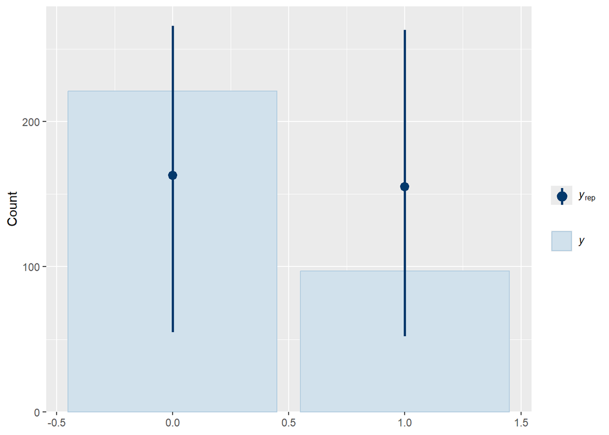

```r
m.prior <-
  brm(data = d, family = bernoulli, formula = f, prior = p,
    iter = 2000, warmup = 1000, chains = 4, cores = 4,
    seed = 4, sample_prior="only",
    file = paste0("../fits/variance.", v[1], ".prior"), file_refit = "on_change"
  )

brms::pp_check(m.prior, ndraws=100, type = "bars", resp = gsub("_", "", v[1]))
```

The prior predictive check (for one of the response variable options) confirms the plausibility of the selected prior probability distribution. Given the number of predictors, the weight towards the extreme values is anticipated. Next, we update the coefficient distributions in light of the collected data using Monte Carlo Markov Chain sampling.

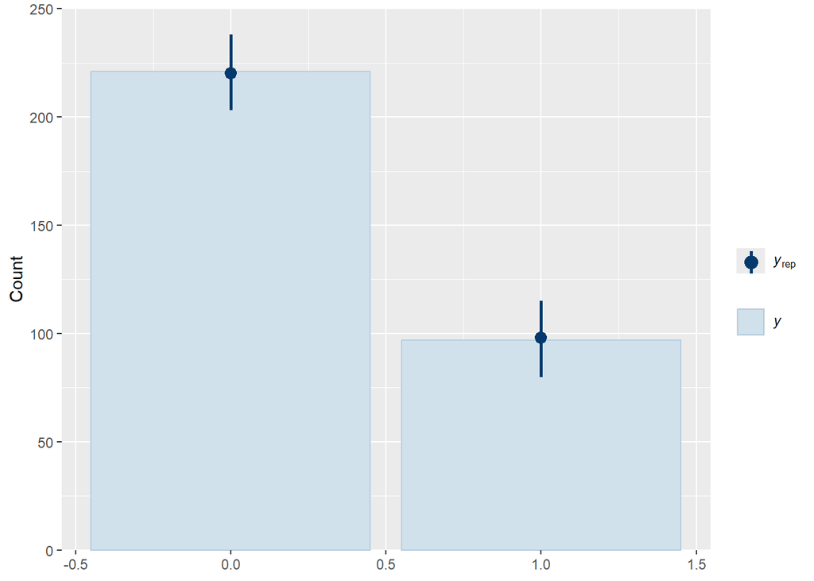

```r
m <-
  brm(data = d, family = bernoulli, formula = f, prior = p,
    iter = 2000, warmup = 1000, chains = 4, cores = 4, seed = 4,
    file = paste0("../fits/variance.", v[1]), file_refit = "on_change"
  )

brms::pp_check(m, ndraws=100, type="bars", resp = gsub("_", "", v[1]))
```

The posterior predictive check (for one of the response variable options) shows that the model predictions ($y_{rep}$) have grown closer to the actually observed data (`y`). This confirms that the model has trained well.

### Evaluation

We visualize the marginal effect of each demographic factor on every response option to determine, (1) whether an option can be viewed as “common”, and (2) whether the levels of the demographic factor affect the responses to this question. First, we investigate the effect of the sector (`v_1`) on all response options.

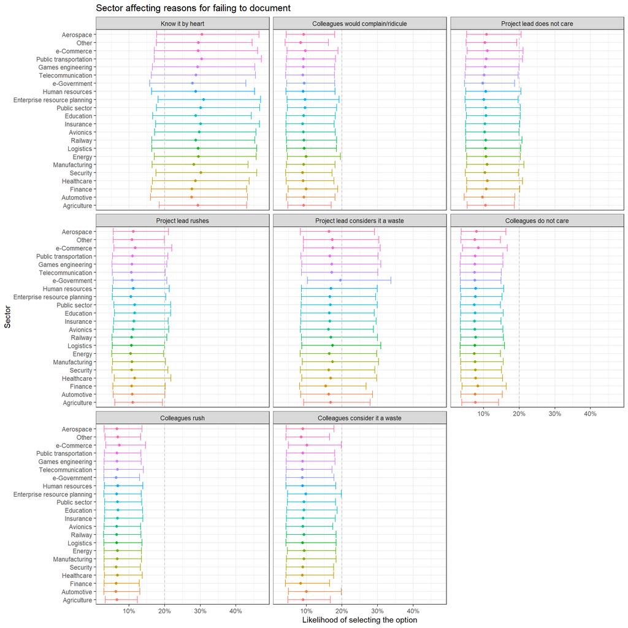

```r
conditional_effects(m, "v_1", prob = 0.95) %>%
  purrr::imap_dfr( ~ {
    purrr::map_dfr(.x, identity) %>%
      mutate(response = str_extract(.y, "^[^.]+"))
  }) %>%
  mutate(
    response = factor(response, levels = gsub("_", "", v),
                      labels = labels, ordered = TRUE)
  ) %>%
  ggplot(aes(y = effect1__, color = effect1__)) +
    geom_point(aes(x = estimate__)) +
    geom_errorbar(aes(xmin = lower__, xmax = upper__)) +
    geom_vline(xintercept = level.common, color = "grey", linetype = "dashed") +
    facet_wrap(~response) +
    scale_x_continuous(labels = scales::percent) +
    labs(x = "Likelihood of selecting the option", y = "Sector") +
    guides(color = "none") +
    ggtitle(paste0("Sector affecting ", q)) +
    theme_bw()
```

The next figure shows the marginal effect of the project size (`v_3`) on the outcomes.

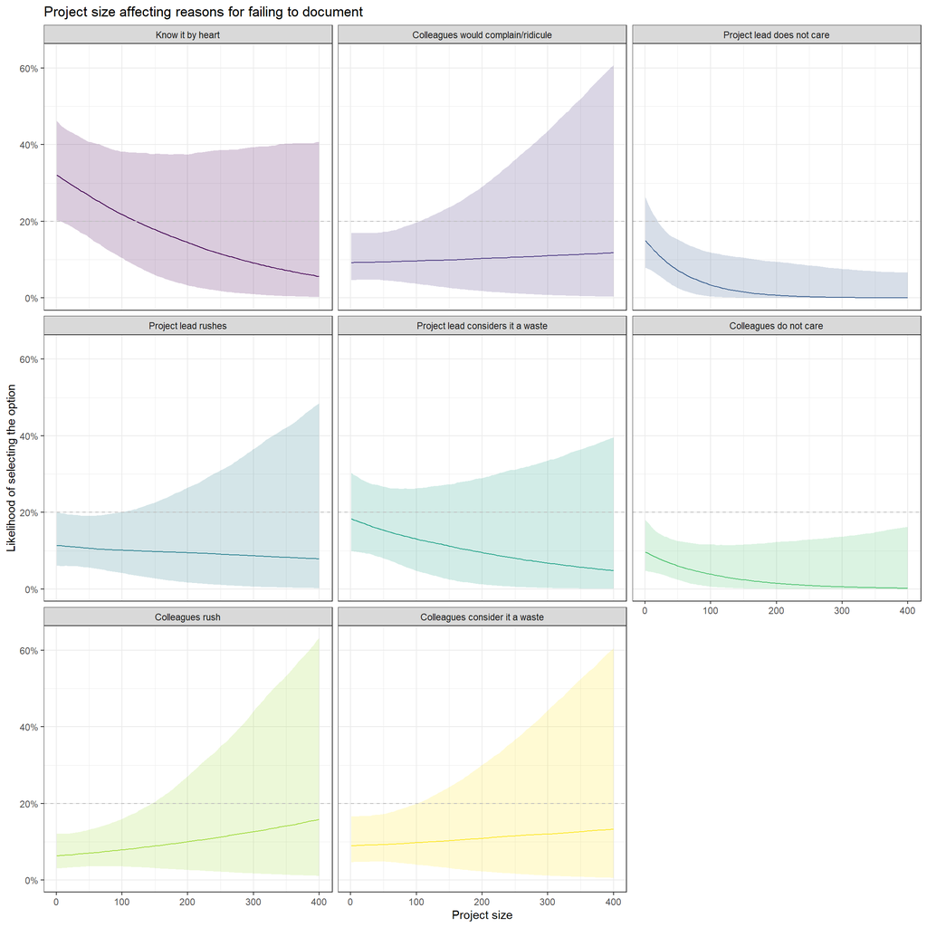

```r
conditional_effects(m, "v_3", prob = 0.95) %>%
  purrr::imap_dfr( ~ {
    purrr::map_dfr(.x, identity) %>%
      mutate(response = str_extract(.y, "^[^.]+"))
  }) %>%
  mutate(
    response = factor(response, levels = gsub("_", "", v),
                      labels = labels, ordered = TRUE)
  ) %>%
  ggplot(aes(x = effect1__)) +
    geom_line(aes(y = estimate__, color = response)) +
    geom_ribbon(aes(ymin = lower__, ymax = upper__, fill = response), alpha = 0.2) +
    geom_hline(yintercept = level.common, color = "grey", linetype = "dashed") +
    facet_wrap(~response) +
    labs(x = "Project size", y = "Likelihood of selecting the option") +
    scale_y_continuous(labels = scales::percent) +
    ggtitle(paste0("Project size affecting ", q)) +
    guides(color = "none", fill = "none") +
    theme_bw()
```

The following figure shows the marginal effect of the country (`Country`) on the outcomes.

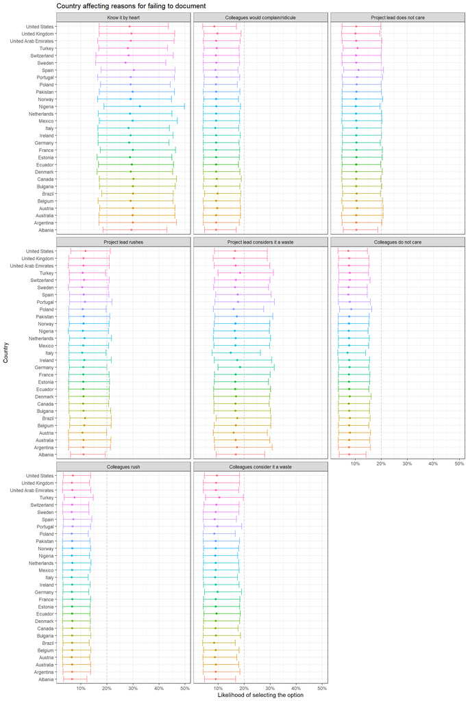

```r
conditional_effects(m, "Country", prob = 0.95) %>%
  purrr::imap_dfr( ~ {
    purrr::map_dfr(.x, identity) %>%
      mutate(response = str_extract(.y, "^[^.]+"))
  }) %>%
  mutate(
    response = factor(response, levels = gsub("_", "", v),
                      labels = labels, ordered = TRUE)
  ) %>%
  ggplot(aes(y = effect1__, color = effect1__)) +
    geom_point(aes(x = estimate__)) +
    geom_errorbar(aes(xmin = lower__, xmax = upper__)) +
    geom_vline(xintercept = level.common, color = "grey", linetype = "dashed") +
    facet_wrap(~response) +
    scale_x_continuous(labels = scales::percent) +
    labs(x = "Likelihood of selecting the option", y = "Country") +
    guides(color = "none") +
    ggtitle(paste0("Country affecting ", q)) +
    theme_bw()
```

The next figure shows the variance induced by the way-of-working (`v_457`).

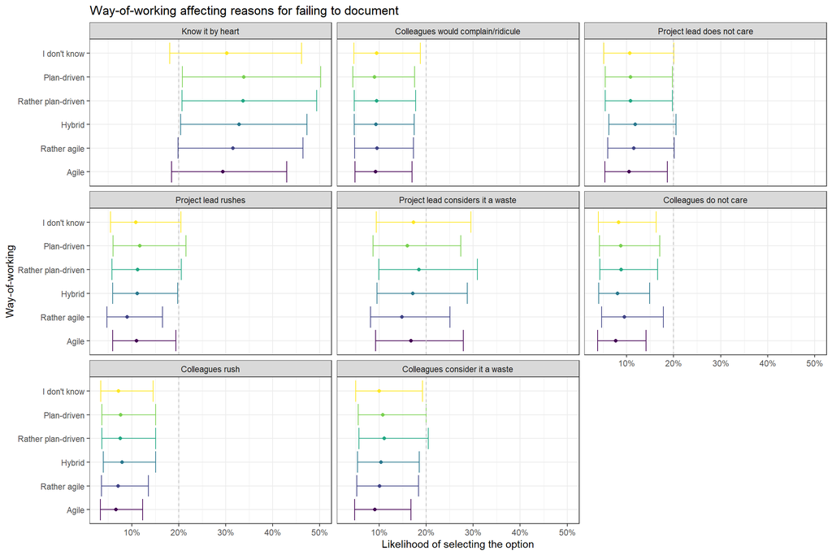

```r
conditional_effects(m, "v_457", prob = 0.95) %>%
  purrr::imap_dfr( ~ {
    purrr::map_dfr(.x, identity) %>%
      mutate(response = str_extract(.y, "^[^.]+"))
  }) %>%
  mutate(
    response = factor(response, levels = gsub("_", "", v),
                      labels = labels, ordered = TRUE)
  ) %>%
  ggplot(aes(y = effect1__, color = effect1__)) +
    geom_point(aes(x = estimate__)) +
    geom_errorbar(aes(xmin = lower__, xmax = upper__)) +
    geom_vline(xintercept = level.common, color = "grey", linetype = "dashed") +
    facet_wrap(~response) +
    scale_x_continuous(labels = scales::percent) +
    labs(x = "Likelihood of selecting the option", y = "Way-of-working") +
    guides(color = "none") +
    ggtitle(paste0("Way-of-working affecting ", q)) +
    theme_bw()
```

The next figure shows the variance induced by whether or not the project includes external partners (`v_16`).

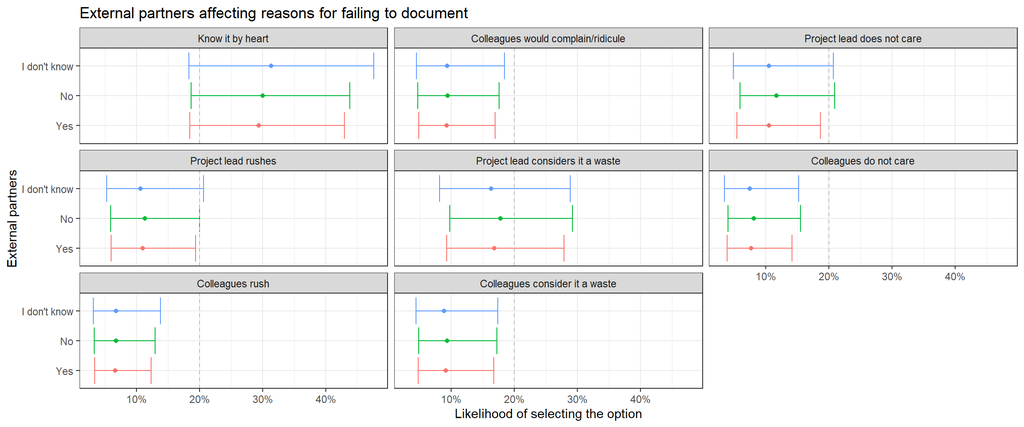

```r
conditional_effects(m, "v_16", prob = 0.95) %>%
  purrr::imap_dfr( ~ {
    purrr::map_dfr(.x, identity) %>%
      mutate(response = str_extract(.y, "^[^.]+"))
  }) %>%
  mutate(
    response = factor(response, levels = gsub("_", "", v),
                      labels = labels, ordered = TRUE)
  ) %>%
  ggplot(aes(y = effect1__, color = effect1__)) +
    geom_point(aes(x = estimate__)) +
    geom_errorbar(aes(xmin = lower__, xmax = upper__)) +
    geom_vline(xintercept = level.common, color = "grey", linetype = "dashed") +
    facet_wrap(~response) +
    scale_x_continuous(labels = scales::percent) +
    labs(x = "Likelihood of selecting the option", y = "External partners") +
    guides(color = "none") +
    ggtitle(paste0("External partners affecting ", q)) +
    theme_bw()
```

The next figure shows the variance induced by whether or not the project is distributed (`v_357`).

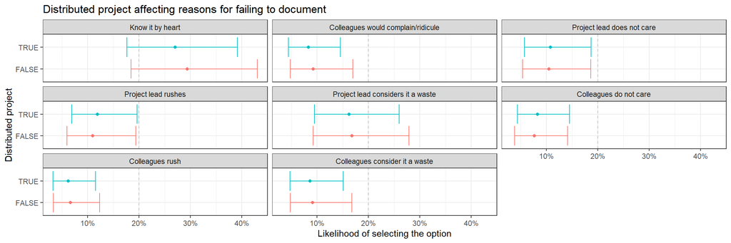

```r
conditional_effects(m, "v_357", prob = 0.95) %>%
  purrr::imap_dfr( ~ {
    purrr::map_dfr(.x, identity) %>%
      mutate(response = str_extract(.y, "^[^.]+"))
  }) %>%
  mutate(
    response = factor(response, levels = gsub("_", "", v),
                      labels = labels, ordered = TRUE)
  ) %>%
  ggplot(aes(y = effect1__, color = effect1__)) +
    geom_point(aes(x = estimate__)) +
    geom_errorbar(aes(xmin = lower__, xmax = upper__)) +
    geom_vline(xintercept = level.common, color = "grey", linetype = "dashed") +
    facet_wrap(~response) +
    scale_x_continuous(labels = scales::percent) +
    labs(x = "Likelihood of selecting the option", y = "Distributed project") +
    guides(color = "none") +
    ggtitle(paste0("Distributed project affecting ", q)) +
    theme_bw()
```

The next figure shows the variance induced by the degree of virtualization (`v_377`).

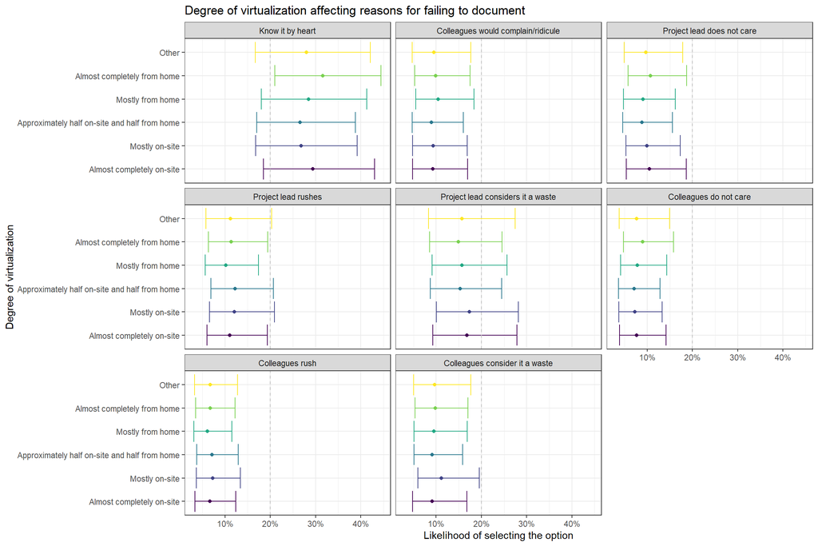

```r
conditional_effects(m, "v_377", prob = 0.95) %>%
  purrr::imap_dfr( ~ {
    purrr::map_dfr(.x, identity) %>%
      mutate(response = str_extract(.y, "^[^.]+"))
  }) %>%
  mutate(
    response = factor(response, levels = gsub("_", "", v),
                      labels = labels, ordered = TRUE)
  ) %>%
  ggplot(aes(y = effect1__, color = effect1__)) +
    geom_point(aes(x = estimate__)) +
    geom_errorbar(aes(xmin = lower__, xmax = upper__)) +
    geom_vline(xintercept = level.common, color = "grey", linetype = "dashed") +
    facet_wrap(~response) +
    scale_x_continuous(labels = scales::percent) +
    labs(x = "Likelihood of selecting the option", y = "Degree of virtualization") +
    guides(color = "none") +
    ggtitle(paste0("Degree of virtualization affecting ", q)) +
    theme_bw()
```

The final figure shows the variance induced by the main role of the participant (`v_17`).

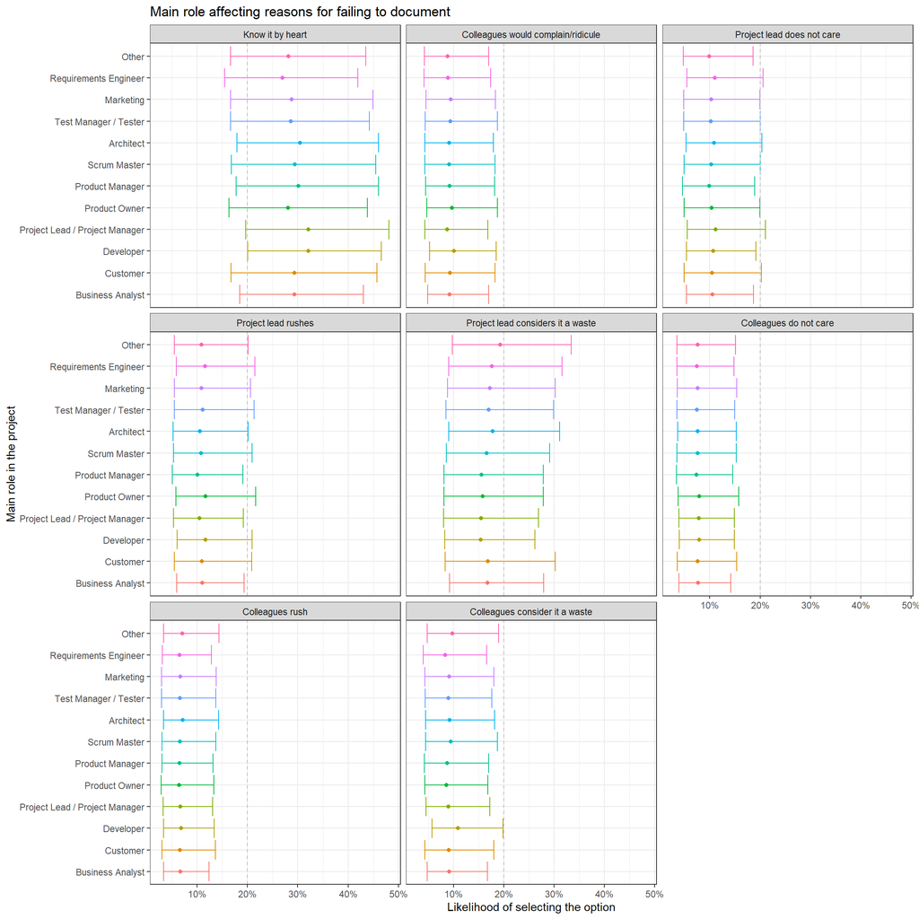

```r
conditional_effects(m, "v_17", prob = 0.95) %>%
  purrr::imap_dfr( ~ {
    purrr::map_dfr(.x, identity) %>%
      mutate(response = str_extract(.y, "^[^.]+"))
  }) %>%
  mutate(
    response = factor(response, levels = gsub("_", "", v),
                      labels = labels, ordered = TRUE)
  ) %>%
  ggplot(aes(y = effect1__, color = effect1__)) +
    geom_point(aes(x = estimate__)) +
    geom_errorbar(aes(xmin = lower__, xmax = upper__)) +
    geom_vline(xintercept = level.common, color = "grey", linetype = "dashed") +
    facet_wrap(~response) +
    scale_x_continuous(labels = scales::percent) +
    labs(x = "Likelihood of selecting the option", y = "Main role in the project") +
    guides(color = "none") +
    ggtitle(paste0("Main role affecting ", q)) +
    theme_bw()
```

[^1]: Siebert, J. (2023). Applications of statistical causal inference in software engineering. Information and Software Technology, 159, 107198.
[^2]: McElreath, R. (2018). Statistical rethinking: A Bayesian course with examples in R and Stan. Chapman and Hall/CRC.